# Section 5 — Bayesian Model Uncertainty

STA5001 R Computational Companion

STA5001 Bayesian & Computational Statistics

Work through the examples in order. Section numbers follow the STA5001 lecture notes, which develop the models and algorithms used here. Open `section-05.Rmd` in RStudio and choose **Knit** to reproduce the outputs. Install BayesComp with `remotes::install_github("sj156/BayesComp", subdir = "BayesComp")` to use the lecture-note figures included in this section.

# Section 5.2 — Evidence and prior sensitivity

**Concept.** A Bayes factor compares the probabilities or densities that two models assign to the data after averaging over their parameters. Multiplying prior odds by the Bayes factor gives posterior odds.

**Example.** After two heads, compare a fair coin with an alternative that gives the head probability a uniform Beta prior. Then use the lecture notes’ standardized normal offset $z=2$ to see how increasing the prior scale changes the evidence for a nonzero offset.

Subtract log marginal likelihoods to form the Bayes factor. For the normal example, use marginal variance $1+s_0^2$ under the alternative and compare its evidence with its conditional posterior mean.

```r
y_binary <- c(1, 1)
n_binary <- length(y_binary)
a0 <- b0 <- 1
log_m0 <- -n_binary * log(2)
log_m1 <- lbeta(a0 + sum(y_binary), b0 + n_binary - sum(y_binary)) -
  lbeta(a0, b0)
bf10 <- exp(log_m1 - log_m0)
prior_odds <- 1 / 3
posterior_m1 <- bf10 * prior_odds / (1 + bf10 * prior_odds)
stopifnot(abs(bf10 - 4/3) < 1e-12,
          abs(posterior_m1 - 4/13) < 1e-12)
c(Bayes_factor=bf10, posterior_alternative=posterior_m1)
```

```
##          Bayes_factor posterior_alternative
##             1.3333333             0.3076923
```

```r
s0 <- c(1, 10, 100)
z <- 2
normal_bf <- exp(-.5 * log1p(s0^2) + z^2 * s0^2 / (2 * (1+s0^2)))
data.frame(s0, posterior_mean=z*s0^2/(1+s0^2),
           Bayes_factor=normal_bf, model_probability=normal_bf/(1+normal_bf))
```

```
##    s0 posterior_mean Bayes_factor model_probability
## 1   1       1.000000   1.92211551         0.6577822
## 2  10       1.980198   0.72082259         0.4188826
## 3 100       1.999800   0.07387209         0.0687904
```

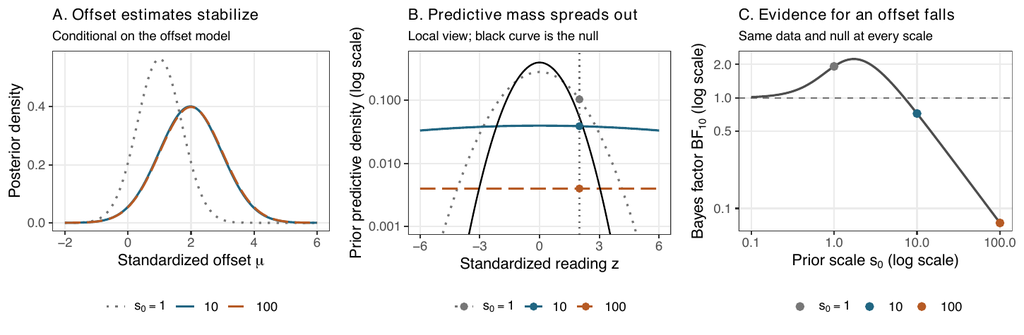

Lecture notes, Section 5.2. The panels compare conditional estimation with model evidence.

The two broad priors give almost the same conditional mean estimate, but very different evidence. As an extension, change the observed value to zero and explain the direction of every Bayes factor.

# Section 5.3 — Prior probabilities over model sizes

**Concept.** Model size aggregates prior probabilities over every subset of a given size. The number of subsets therefore matters when translating between priors on models and priors on model size.

**Example.** For two candidate predictors, compare fixed independent inclusion with probability $1/2$ to a shared inclusion probability drawn from a uniform Beta distribution.

Enumerate the four subsets, integrate each model probability using a beta-function ratio, then sum the model probabilities by size.

```r
gamma_small <- as.matrix(expand.grid(gamma1=0:1, gamma2=0:1))
size_small <- rowSums(gamma_small)
prior_fixed <- rep(1/4, 4)
a0 <- b0 <- 1
prior_mixed <- exp(lbeta(a0 + size_small, b0 + 2 - size_small) - lbeta(a0,b0))
stopifnot(abs(sum(prior_mixed)-1) < 1e-12)
data.frame(gamma_small, size=size_small, prior_fixed, prior_mixed)
```

```
##   gamma1 gamma2 size prior_fixed prior_mixed
## 1      0      0    0        0.25   0.3333333
## 2      1      0    1        0.25   0.1666667
## 3      0      1    1        0.25   0.1666667
## 4      1      1    2        0.25   0.3333333
```

```r
sapply(0:2, function(s) sum(prior_mixed[size_small==s]))
```

```
## [1] 0.3333333 0.3333333 0.3333333
```

For 20 predictors, compute the total probability of each size by multiplying single-model probability by the number of models of that size. The third prior puts more mass on smaller models.

```r
size <- 0:20
size_mass <- cbind(
  equal_models = dbinom(size, 20, .5),
  equal_sizes = rep(1 / 21, 21),
  sparse = exp(lchoose(20, size) + lbeta(1 + size, 40 - size) - lbeta(1, 20))
)
stopifnot(all(abs(colSums(size_mass) - 1) < 1e-12))
rbind(empty = size_mass[1, ], size_10 = size_mass[11, ],
      expected_size = drop(crossprod(size, size_mass)))
```

```
##               equal_models equal_sizes       sparse
## empty         9.536743e-07  0.04761905 0.5000000000
## size_10       1.761971e-01  0.04761905 0.0001453066
## expected_size 1.000000e+01 10.00000000 0.9523809524
```

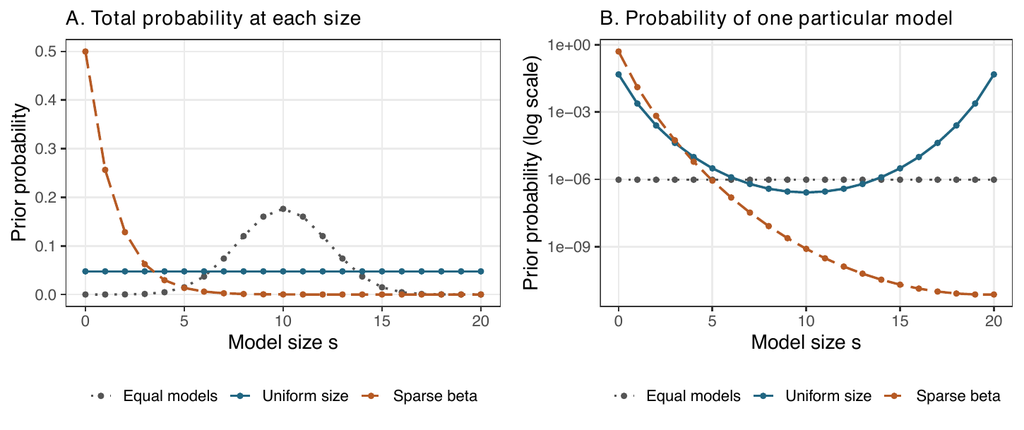

Lecture notes, Section 5.3. The left panel shows aggregate size probabilities and the right shows per-model probabilities.

The mixed prior gives probabilities $(1/3,1/6,1/6,1/3)$ to the four models. Try a beta prior with $(a_0,b_0)=(1,2)$ and compare its expected size with the fixed-inclusion prior having the same mean inclusion rate.

# Section 5.4 — Exact enumeration and predictive uncertainty

**Concept.** When the model space is small enough to enumerate, normalize the evidence-weighted prior probabilities directly. Model averaging then uses those posterior weights to mix whole predictive distributions.

**Example.** Use the five artificial observations in the notes. The two predictors are centered, and all variables are dimensionless. The four models include every predictor subset and always an intercept. Use $g_0=5$, equal model priors, and the shared nuisance prior $p(\alpha,\sigma^2)\propto1/\sigma^2$ with the same constant in every model. The computed evidences are ratios against the intercept-only model.

Compute the explained sum of squares for each subset, then transform its fraction of the total into a Bayes factor. Normalize on the log scale, sum weights for models that include each predictor, and average the predictive variances at $(0,0)$, where the component means coincide.

```r
dat5 <- data.frame(x1=c(-2,-1,0,1,2), x2=c(2,-1,-2,-1,2),
                   y=c(-1,0,1,1,4))
dat5
```

```
##   x1 x2  y
## 1 -2  2 -1
## 2 -1 -1  0
## 3  0 -2  1
## 4  1 -1  1
## 5  2  2  4
```

```r
x5 <- as.matrix(dat5[c('x1','x2')])
yc5 <- dat5$y - mean(dat5$y)
n5 <- nrow(dat5)
g0 <- 5
gamma5 <- as.matrix(expand.grid(gamma1=0:1,gamma2=0:1))
size5 <- rowSums(gamma5)
r2_5 <- apply(gamma5, 1, function(included) {
  if (!any(included)) return(0)
  xs <- x5[, included==1, drop=FALSE]
  beta_hat <- solve(crossprod(xs),crossprod(xs,yc5))
  sum((xs %*% beta_hat)^2)/sum(yc5^2)
})
log_bf5 <- (n5-1-size5)/2*log1p(g0) -
  (n5-1)/2*log1p(g0*(1-r2_5))
normalize_log <- function(log_weights) {
  w <- exp(log_weights-max(log_weights))
  w/sum(w)
}
w5 <- normalize_log(log_bf5 + log(rep(.25,4)))
pip5 <- drop(crossprod(w5,gamma5))
q5 <- sum(yc5^2)*(1-g0*r2_5/(1+g0))
# At centered predictors (0,0), all predictive means are the sample mean.
# Integrating sigma^2 gives t_(n-1), with finite variance for n>3.
a_n5 <- (n5-1)/2
b_n5 <- q5/2
v5 <- (1+1/n5)*b_n5/(a_n5-1)
bma_variance5 <- sum(w5*v5)
data.frame(gamma5, R2=r2_5, BF=exp(log_bf5), posterior_weight=w5,
           predictive_variance=v5)
```

```
##   gamma1 gamma2         R2        BF posterior_weight predictive_variance
## 1      0      0 0.00000000 1.0000000       0.10509431            8.400000
## 2      1      0 0.86428571 5.2161158       0.54818407            2.350000
## 3      0      1 0.04591837 0.4413812       0.04638665            8.078571
## 4      1      1 0.91020408 2.8577663       0.30033497            2.028571
```

```r
c(PIP1=pip5[1], PIP2=pip5[2], mean=mean(dat5$y), variance=bma_variance5)
```

```
## PIP1.gamma1 PIP2.gamma2        mean    variance
##   0.8485190   0.3467216   1.0000000   3.1550135
```

```r
# Independent checks: sum of probabilities, projection decomposition,
# normalization invariance, and direct marginal-likelihood integration.
stopifnot(abs(sum(w5)-1)<1e-12,
          abs(r2_5[4]-r2_5[2]-r2_5[3])<1e-12,
          max(abs(normalize_log(log_bf5-10000)-w5))<1e-10)
int5 <- vapply(seq_along(q5),function(j) {
  integrate(function(variance) (1+g0)^(-size5[j]/2) *
    variance^(-a_n5-1)*exp(-q5[j]/(2*variance)),
    0,Inf,rel.tol=1e-9)$value
},numeric(1))
stopifnot(max(abs(int5/int5[1]-exp(log_bf5)))<1e-7)
# Check the predictive variance against the t distribution's moments.
t_scale2 <- (1+1/n5)*q5/(n5-1)
stopifnot(max(abs(t_scale2*(n5-1)/(n5-3)-v5))<1e-12)
```

The full model explains more variation, but the first-predictor-only model has higher posterior probability. At the centered prediction point, model means agree while their predictive variances differ. The mixture retains uncertainty even though the between-model mean term is zero.

Reweight the same likelihoods using an inclusion probability of 1/4. Evaluate the four Student predictive densities on a common grid, then plot the mixture for each model prior.

```r
omega <- .25
prior_sparse <- omega^size5*(1-omega)^(2-size5)
w_sparse <- normalize_log(log_bf5 + log(prior_sparse))
data.frame(gamma5, prior_sparse, posterior_weight=w_sparse)
```

```
##   gamma1 gamma2 prior_sparse posterior_weight
## 1      0      0       0.5625       0.31217203
## 2      1      0       0.1875       0.54277516
## 3      0      1       0.1875       0.04592895
## 4      1      1       0.0625       0.09912386
```

```r
c(PIP1=sum(w_sparse*gamma5[,1]), PIP2=sum(w_sparse*gamma5[,2]),
  predictive_variance=sum(w_sparse*v5))
```

```
##                PIP1                PIP2 predictive_variance
##           0.6418990           0.1450528           4.4698868
```

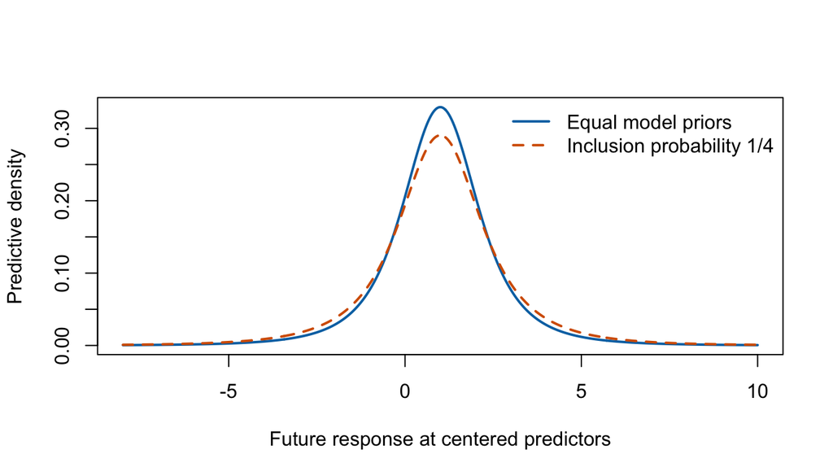

```r
y_future <- seq(-8,10,length.out=501)
dens5 <- sapply(seq_along(w5),function(j)
  dt((y_future-mean(dat5$y))/sqrt(t_scale2[j]),df=n5-1)/sqrt(t_scale2[j]))
plot(y_future,drop(dens5 %*% w5),type='l',lwd=2,col='#0072B2',
     xlab='Future response at centered predictors',ylab='Predictive density')
lines(y_future,drop(dens5 %*% w_sparse),lwd=2,lty=2,col='#D55E00')
legend('topright',c('Equal model priors','Inclusion probability 1/4'),
       col=c('#0072B2','#D55E00'),lty=c(1,2),lwd=2,bty='n')
```

As an extension, vary $g_0$ over $1,5,25$ and recompute both model weights and within-model predictive variances. Changing only the weights would miss the scale’s effect on the conditional predictions.

R 4.6.0 · BayesComp 0.1.0